# Plotting Electric Vehicle Open Data

with ggplot2 and friends

Data Scientist

[Alexander J. Senetcky, BS, MPH](https://asenetcky.dev)

Published

June 10, 2025

## 1 Goal

Today we’re going to:

- Introduce plotting with R and the `ggplot2` package
- Provide resources for further reading
- Highlight some best practices

## 2 The Setup

I’ll be using `renv` - however, `renv` is not the focus of today. Plotting in R using the `ggplot2` package is. Be sure to check out the doco [here](https://rstudio.github.io/renv/). We’re going to start by attaching the libraries with `library()`.

```r
# suppressing the startup messages
library(tidyverse) |> suppressPackageStartupMessages()

# ggplot2 is a core tidyverse package so it's
# included in the namespace when folks `library(tidyverse)`
```

## 3 The Data

Today we’re going to use the Electric Vehicle data from our #tidytuesday community [challenge](https://github.com/CTOpenData/r-user-group/tree/d748587f4802578325b6a9d55c59b71563ba260d/tidy-tuesday).

### 3.1 Grabbing the Data

Unfortunately, `RSocrata` was pulled from the CRAN - so we’re going to have to homebrew our own solution.

Fortunately, I put together a gist on github. You may recall Charles Powell introduced these last year. You can take a look at the gist [here](https://gist.github.com/asenetcky/52bf3fa10a2dff08f62da96e2347e018).

We can use `devtools` to source the gist and grab the function I wrote to download *all* the EV data.

**Tip**

`devtools` is a collection of packages, like the `tidyverse` that aims to smmoth over alot of *rough edges* in development. Primarily around building R packages or interacting with **GitHub**, but there is all sorts of neat things in `devtools` - so be sure to check it out.

```r
devtools::source_gist(
  id = "https://gist.github.com/asenetcky/52bf3fa10a2dff08f62da96e2347e018",
  sha1 = "5b27e785462239543a6cda235382ebec7c381471"
)
```

```
ℹ Sourcing gist "52bf3fa10a2dff08f62da96e2347e018"
```

```r
# function exist?
head(pull_odp)
```

```
1 function (domain = "https://data.ct.gov/", resource)
2 {
3     checkmate::assert(checkmate::check_string(domain), checkmate::check_string(resource,
4         n.chars = 9L), combine = "and")
5     resource_string <- glue::glue("resource/{resource}.json")
6     limit <- 10000
```

We have our function, now lets grab that open data.

```r
ev <- pull_odp(resource = "y7ky-5wcz") # this is the ODP "four by four"
```

### 3.2 Data Recon

Lets take a look at this dataset so we can have a better idea of what we are working with.

```r
head(ev)
```

```
# A tibble: 6 × 20
  id      platetype primarycustomercity primarycustomerstate
  <chr>   <chr>     <chr>               <chr>
1 2951643 Passenger ARMONK              NY
2 2945023 Passenger AVON                CT
3 2948019 Passenger AVON                CT
4 2318395 Passenger AVON                CT
5 2952422 Passenger BETHANY             CT
6 2952920 Passenger BOLTON              CT
# ℹ 16 more variables: registration_date_start <chr>,
#   registration_date_expiration <chr>, registrationusage <chr>,
#   vehicletype <chr>, vehicleweight <chr>, vehicleyear <chr>,
#   vehiclemake <chr>, vehiclemodel <chr>, vehiclebody <chr>,
#   primarycolor <chr>, vehicledeclaredgrossweight <chr>, fuelcode <chr>,
#   vehiclerecordedgvwr <chr>, vehicle_name <chr>, type <chr>,
#   vehicle_category <chr>
```

```r
glimpse(ev)
```

```
Rows: 60,489
Columns: 20
$ id                           <chr> "2951643", "2945023", "2948019", "2318395…
$ platetype                    <chr> "Passenger", "Passenger", "Passenger", "P…
$ primarycustomercity          <chr> "ARMONK", "AVON", "AVON", "AVON", "BETHAN…
$ primarycustomerstate         <chr> "NY", "CT", "CT", "CT", "CT", "CT", "CT",…
$ registration_date_start      <chr> "2024-12-31T00:00:00.000", "2024-12-31T00…
$ registration_date_expiration <chr> "2027-12-30T00:00:00.000", "2027-12-30T00…
$ registrationusage            <chr> "Regular", "Regular", "Regular", "Regular…
$ vehicletype                  <chr> "SUV", "SUV", "SUV", "Passenger", "Passen…
$ vehicleweight                <chr> "0", "0", "0", "0", "0", "0", "0", "0", "…
$ vehicleyear                  <chr> "2025", "2024", "2025", "2022", "2019", "…
$ vehiclemake                  <chr> "Audi", "Cadillac", "Tesla", "Volvo", "Te…
$ vehiclemodel                 <chr> "Q5 E Premium 55", "Lyriq Lux", "Model Y"…
$ vehiclebody                  <chr> "SU", "SU", "SU", "SU", "4D", "4D", "SU",…
$ primarycolor                 <chr> "Gray", "Gray", "White", "Black", "Blue",…
$ vehicledeclaredgrossweight   <chr> "0", "0", "0", "808040", "0", "0", "0", "…
$ fuelcode                     <chr> "H04", "E00", "E00", "H04", "E00", "E00",…
$ vehiclerecordedgvwr          <chr> "0", "0", "0", "0", "0", "0", "0", "0", "…
$ vehicle_name                 <chr> "Audi Q5 Plug In", "Cadillac Lyriq", "Tes…
$ type                         <chr> "PHEV", "BEV", "BEV", "PHEV", "BEV", "BEV…
$ vehicle_category             <chr> "Light-Duty (Class 1-2)", "Light-Duty (Cl…
```

So we have `20` columns and `60,489` rows.

### 3.3 Quick Wrangle!

> I don’t want to spoil anyone’s sense of discovery with these data. So I am going to just quickly wrangle it and skip over it, but feel free to take a look at the source code when you have time. Or after you’re done experimenting with it.

```r
data <-
  ev |>
  mutate(
    across(
      .cols = c(
        id,
        vehicleweight,
        vehicleyear,
        vehicledeclaredgrossweight,
        vehiclerecordedgvwr,
      ),
      .fns = as.numeric
    ),
    across(
      .cols = c(
        registration_date_start,
        registration_date_expiration
      ),
      .fns = as_date
    )
  )

char_data <-
  data |>
  select(where(is.character))

char_data <-
  data |>
  select(where(is.character))

maybe_factors <-
  map(
    char_data,
    \(var) {
      count(char_data, {{ var }}, sort = TRUE)
    }
  ) |>
  keep(\(df) nrow(df) < 100) |>
  names()

ev <-
  data |>
  mutate(
    across(
      .cols = all_of(maybe_factors),
      .fns = \(col) {
        col |>
          forcats::as_factor() |>
          forcats::fct_infreq()
      }
    )
  )
```

## 4 ggplot2 and friends

`ggplot2` is now over 10 years old and a stable and trusted package for visualizations. It is based on the core philosphy around Leland Wilkinson’s *The Grammar of Graphics*.

> *Wilkinson, L. (2005), The Grammar of Graphics, 2nd ed., Springer.*

If you like, you can read up on how `ggplot2` incorporates those ideals [ggplot2: Elegant Graphics for Data Analysis (3e)](https://ggplot2-book.org/).

It’s probably safe to say it is a cornerstone of the R community.  
The examples, and [documentation](https://ggplot2.tidyverse.org/) you can find online is often extensive and well written. `python` even has a port of it with the `plotnine` package.

### 4.1 Syntax: a note about `+`

Right away folks are going to notice that `ggplot2` uses a different syntax than the usual base pipe `|>` or maggritr pipe `%>%` that you will often see out in the wild. This is primarily down to how old the package is, however, I find that `+` more accurately describes the thought process involved with crafting a plot.

**Tip**

With pipes, actions happen linearly in order, whereas with `+` you can think of `ggplot2` plots like building up a layer cake. You are *adding* layers, quite literally with a `+`. The order of the layers doesn’t matter *quite* as much as the whole.

## 5 ggplot 2 in action

`ggplot2` is fairly flexible in how you structure your commands, so you’re likley to see some variations between developers.

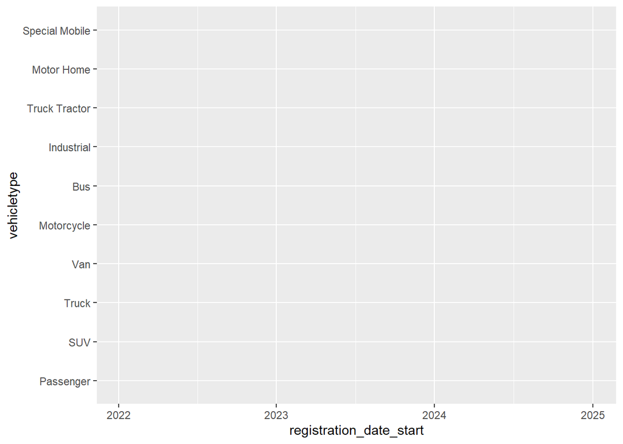

```r
# we can start with the data, or a call to `ggplot()`
# I prefer starting with the data and piping it in, otherwise
# folks can use ggplot(data = ev, ...)

ev |>
  ggplot(
    mapping = aes(
      # we're mapping our aesthetic, think of it like a base we pin layers to
      x = registration_date_start, # x axis
      y = vehicletype # y axis
    )
  )
```

If we just run the above, we’ll get a blank plot. However, take a quick look at that - so much of the stage has already been laid out for us. `ggplot2` has fairly sensible defaults, so for the folks who want to get in and get out quickly, they can do that. This allows plotting and visualizations to be used as one part of an exploratory analysis, and not just as a final, finished product, because it is so quick and easy to do once users are acquainted with `ggplot2`.

### 5.1 Adding Details

How about we fill in some useful details, no?

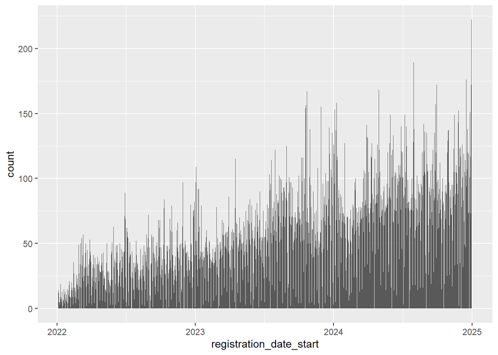

```r
# Let's add some layers!
ev |>
  ggplot(
    mapping = aes(
      # we're mapping our aesthetic, think of it like a base we pin layers to
      x = registration_date_start # x axis
    )
  ) +
  geom_bar() # How about some bars?
```

You can combine `geom_` layers!

We can have one geom:

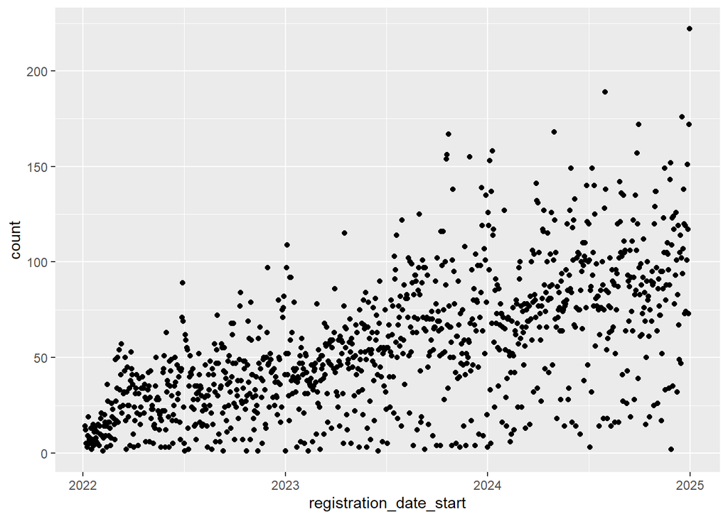

```r
count_by_day <-
  ev |>
  count(registration_date_start, name = "count")

count_by_day |>
  ggplot(
    mapping = aes(
      x = registration_date_start,
      y = count
    )
  ) +
  geom_point()
```

Or two - sharing the same aesthetic and variables

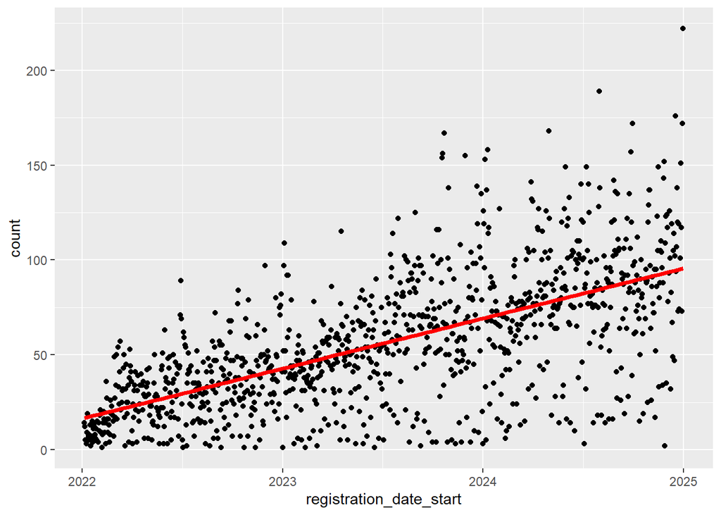

```r
count_by_day |>
  ggplot(
    mapping = aes(
      x = registration_date_start,
      y = count
    )
  ) +
  geom_point() +
  geom_smooth(
    method = "lm",
    se = FALSE,
    color = "red",
    linewidth = 1.5
  ) |>
    suppressMessages()
```

Goodness there is alot going on there!

Does day of week make a difference? Let’s find out.

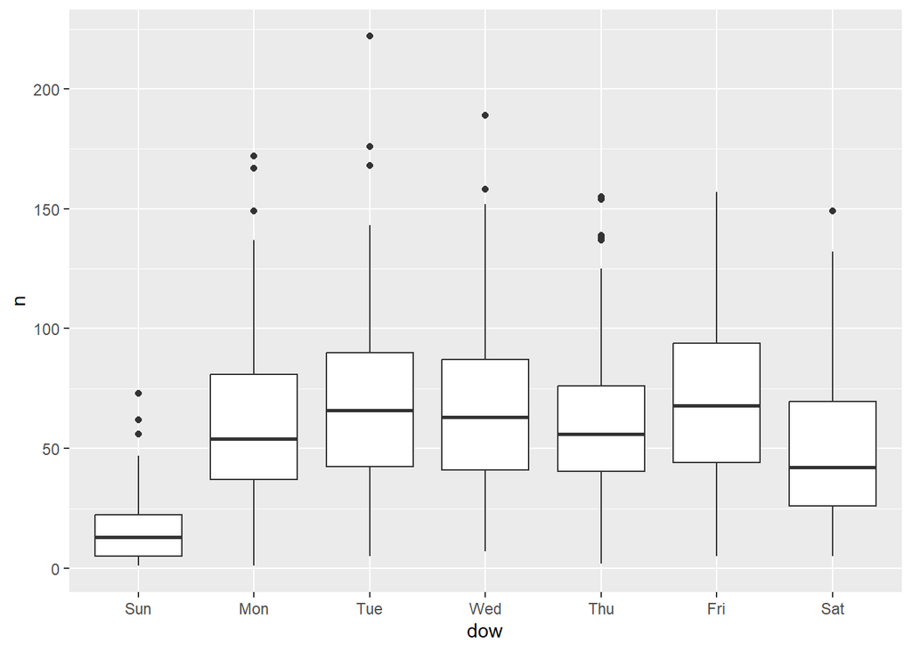

```r
ev |>
  select(registration_date_start) |>
  mutate(
    dow = wday(
      registration_date_start,
      label = TRUE
    )
  ) |>
  count(registration_date_start, dow) |>
  ggplot() +
  geom_boxplot(aes(dow, n))
```

Notice again that we had some fairly sensible defaults, without having to dig into all the arguments of the functions.

### 5.2 The Ask

Pretend for a moment that our supervisor wants to compare the `vehicletype` over `time`. We’ll do another quick wrangle so we can more easily compare types over time.

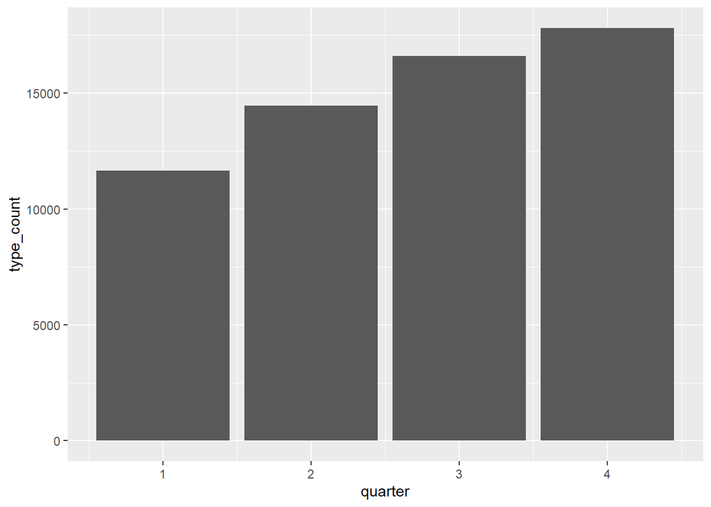

```r
agg_by_year_quarter_type <-
  ev |>
  mutate(
    year = year(registration_date_start),
    quarter = quarter(registration_date_start),
    vehicletype = forcats::fct_lump_prop(
      vehicletype,
      prop = .01
    )
  ) |>
  count(year, quarter, vehicletype, name = "type_count")

agg_by_year_quarter_type |>
  ggplot() +
  geom_col(
    aes(
      x = quarter,
      y = type_count
    )
  )
```

what about year and quarter?

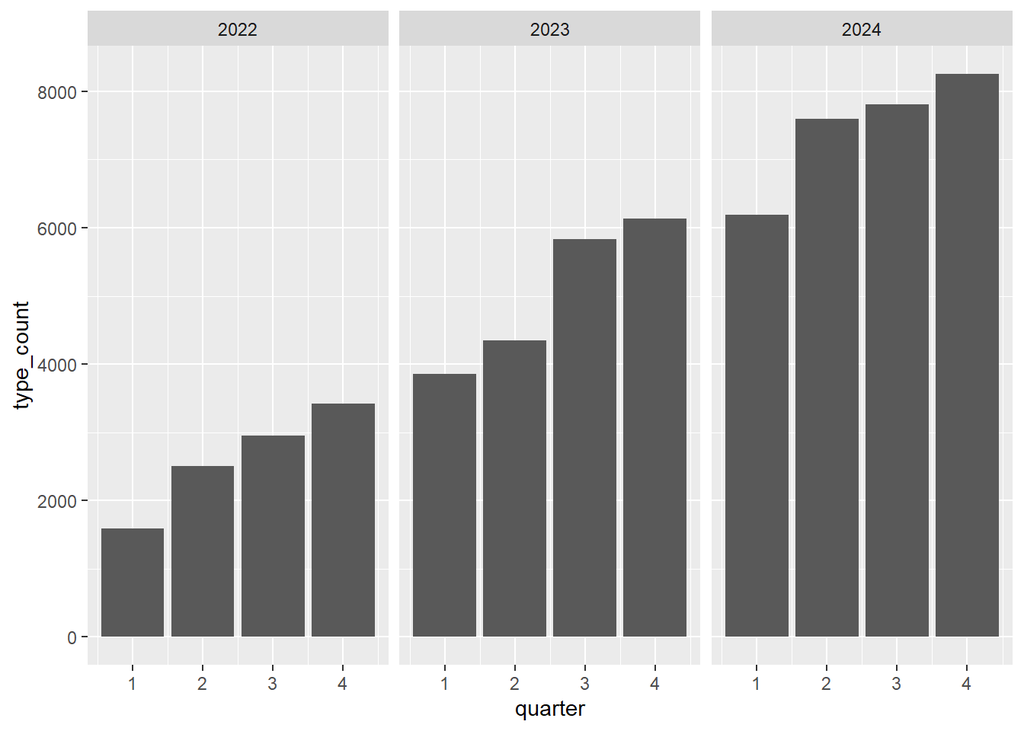

```r
agg_by_year_quarter_type |>
  ggplot() +
  geom_col(
    aes(
      x = quarter,
      y = type_count
    )
  ) +
  facet_grid(cols = vars(year))
```

### 5.3 Adding Color based on Features in the Data

Didn’t we want to compare `vehicletype`? let’s do that….but how?

Using color!

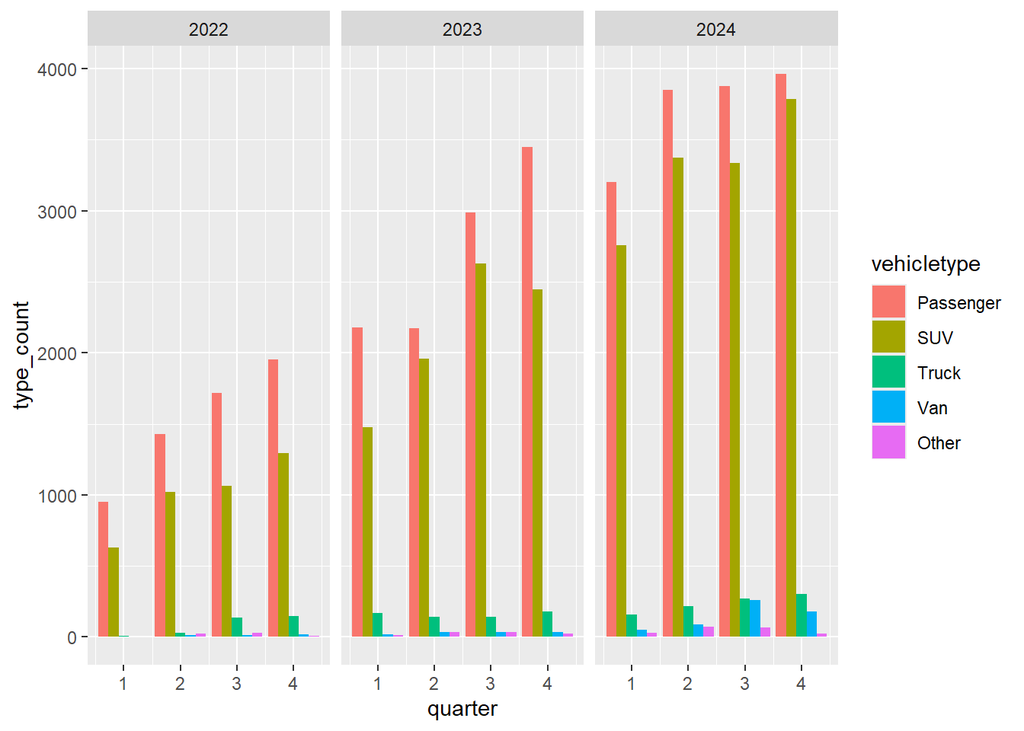

```r
agg_by_year_quarter_type |>
  ggplot() +
  geom_col(
    aes(
      x = quarter,
      y = type_count,
      # now colors are added to break out based on values in the data
      fill = vehicletype
    ),
    position = position_dodge()
  ) +
  facet_grid(cols = vars(year))
```

Let’s natural log transform these data to get rid of that skew.

```r
# using lubridate and forcats
agg_by_year_quarter_type <-
  agg_by_year_quarter_type |>
  mutate(log_type = log(type_count))

head(agg_by_year_quarter_type)
```

```
# A tibble: 6 × 5
   year quarter vehicletype type_count log_type
  <dbl>   <int> <fct>            <int>    <dbl>
1  2022       1 Passenger          949    6.86
2  2022       1 SUV                627    6.44
3  2022       1 Truck               10    2.30
4  2022       1 Van                  5    1.61
5  2022       1 Other                2    0.693
6  2022       2 Passenger         1428    7.26
```

And try again.

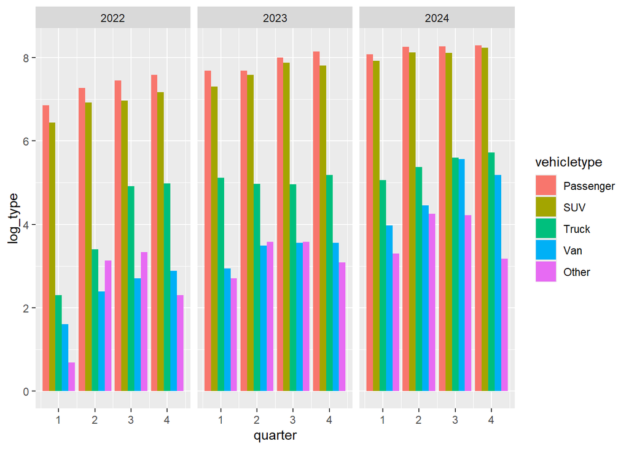

```r
agg_by_year_quarter_type |>
  ggplot() +
  geom_col(
    aes(quarter, log_type, fill = vehicletype),
    position = position_dodge()
  ) +
  facet_grid(cols = vars(year))
```

Now, I want to save some typing. `ggplot2` objects can be saved and combined in fun and exciting ways.

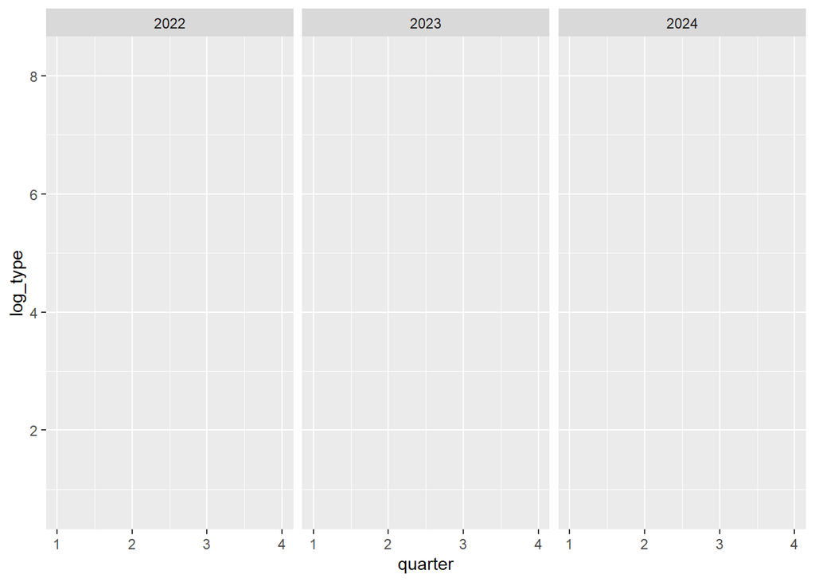

```r
base <-
  agg_by_year_quarter_type |>
  ggplot(
    aes(quarter, log_type, fill = vehicletype)
  ) +
  facet_grid(cols = vars(year))

base
```

Nothing in that plot until we add a `geom_`. So just like our plot with the points and the trendline where we combined `geom_`’s in one end to end statement - you can combine *saved* `ggplot2` objects with `geom_`’s as well.

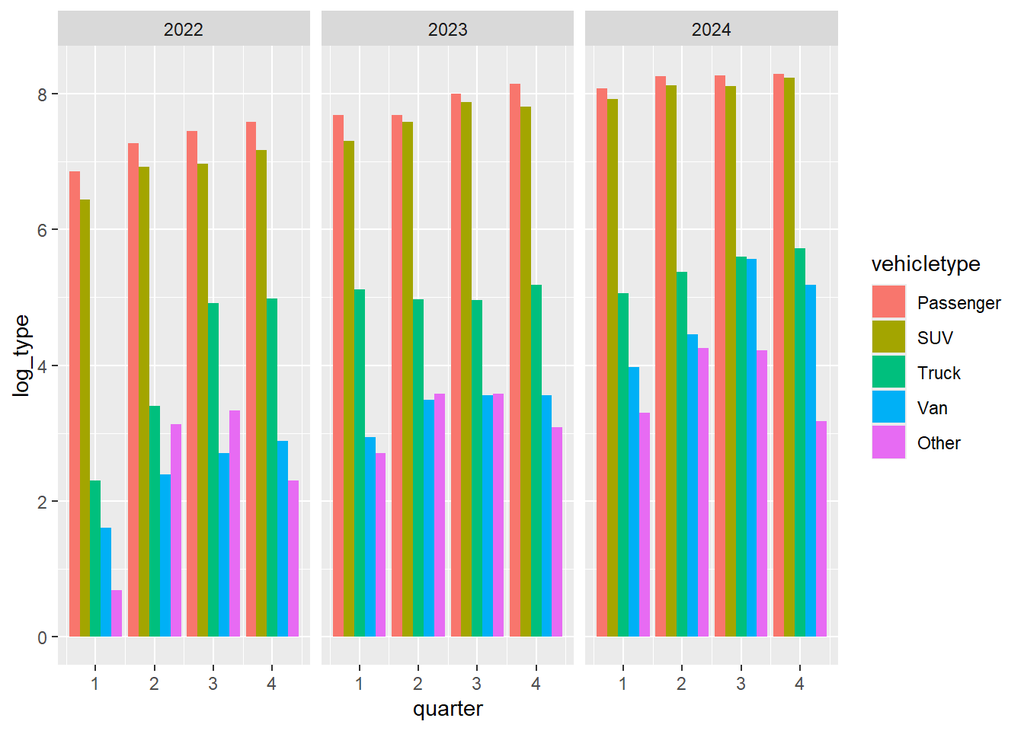

```r
col_base <- base + geom_col(position = position_dodge())
col_base
```

Cool… now we can focus on making this look nicer.

### 5.4 Tweaking the look and feel

`ggplot2` has a number of built in themes, and you can even make your own. State of Connecticut has some newish style specifications, sounds like a great theme to make and have on hand. Why not ship it in an R package?

**Tip**

OPM took that style spec and ran with it in their publication: [CT Data Visualization Guidelines](https://ctopendata.github.io/data-visualization-guidelines/)

Here are some common built-in themes:

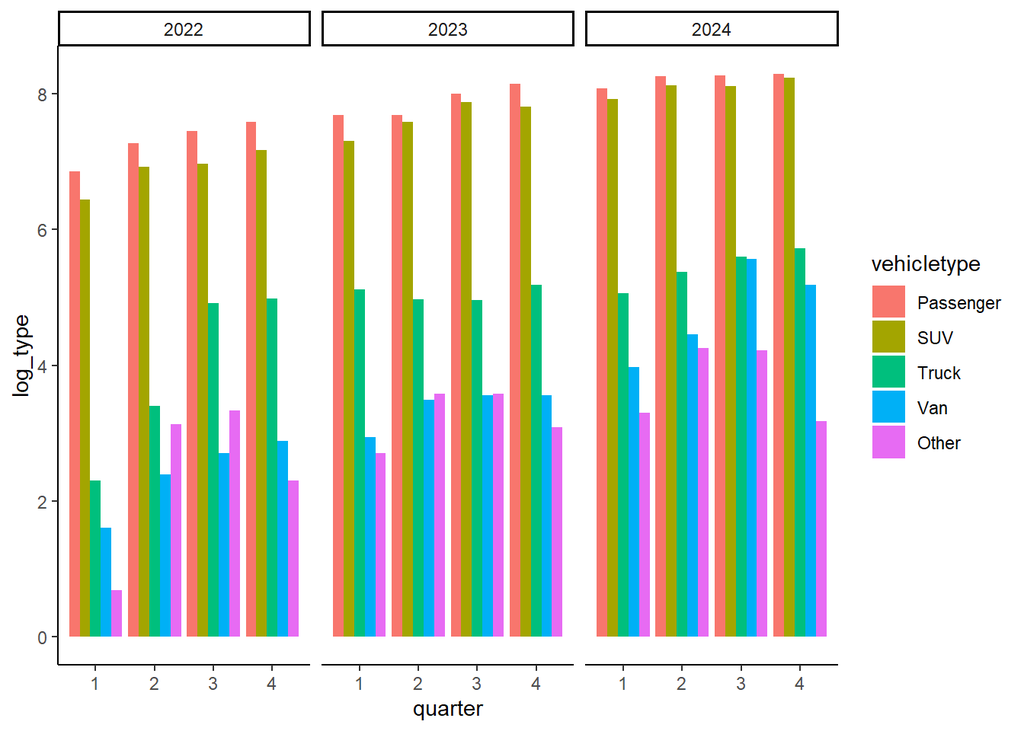

```r
# there are many to choose from - and you can even build your own!

col_base + theme_classic()
```

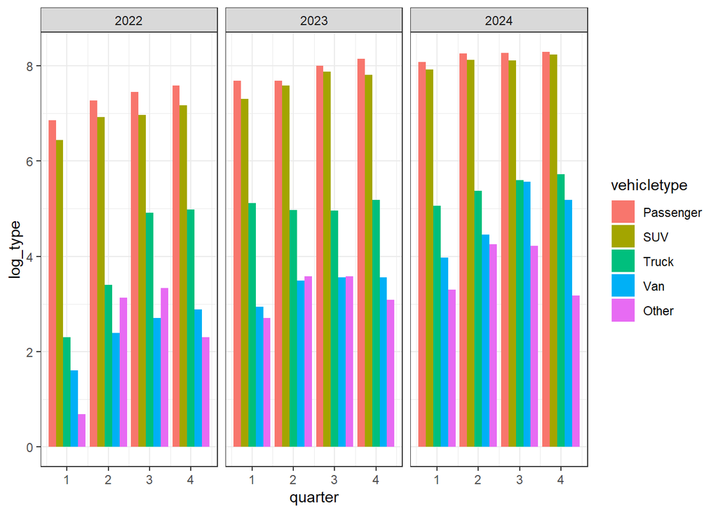

```r
col_base + theme_bw()
```

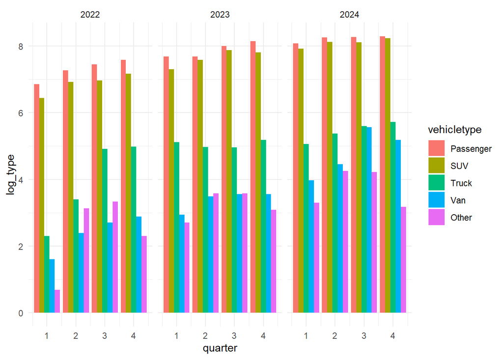

```r
col_base + theme_minimal()
```

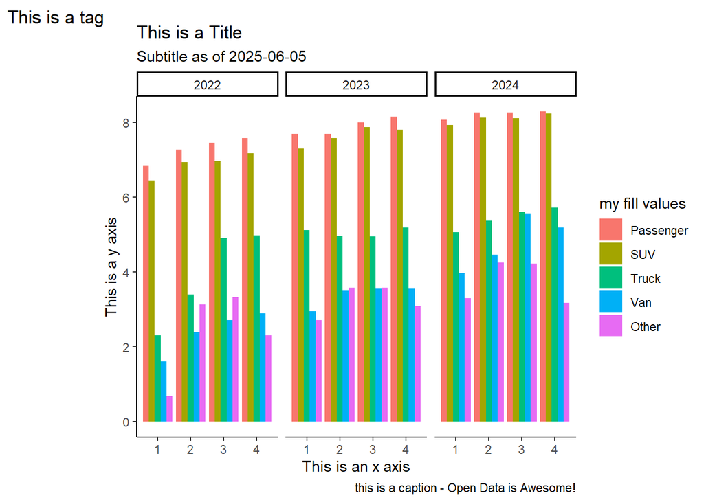

```r
# now for the labels
with_labels <-
  col_base +
  theme_classic() +
  # add some labels
  labs(
    title = "This is a Title",
    subtitle = paste("Subtitle as of", lubridate::today()),
    caption = "this is a caption - Open Data is Awesome!",
    tag = "This is a tag",
    # the next bit refers to the mapped variables x, y etc... BUT it may
    # not always be x and y
    x = "This is an x axis",
    y = "This is a y axis",
    fill = "my fill values"
  )

with_labels
```

### 5.5 Opinionated Polish

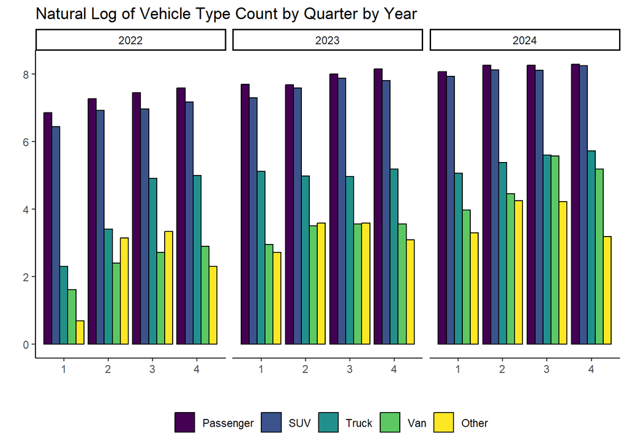

```r
base +
  geom_col(
    position = position_dodge(), # I want bars side by side, not stacked
    col = "black" # just a black outline
  ) +
  scale_fill_viridis_d() + # use viridis color scale
  theme_classic() + # we can use a default theme
  theme(
    # and add our own components!
    legend.position = "bottom",
    legend.direction = "horizontal"
  ) +
  labs(
    x = "", # I don't want axis labels
    y = "",
    fill = "",
    title = "Natural Log of Vehicle Type Count by Quarter by Year"
  )
```